# Number of membership associations per 10,000 people — County

Author

Manuel Alcalá Kovalski

Published

October 28, 2025

## Housekeeping

- 1. import and clean the data file
- 2. download population data from ACS (this is the denominator)
- 3. merge the data file(s) & construct the ratio (Numerator/Denominator)
- 4. final file cleaning and export to .csv file

```r
library(tidyverse)
library(here)
library(sf)
library(censusapi)
library(tigris)
library(naniar)
options(tigris_use_cache = TRUE)
```

## Import and clean the CBP data file

This means: a) fill in fips missing zeroes,  
b) isolate to only the following NAICS,  
c) collapse & keep only relevant variables, and  
d) add the year of these data.

We pull our data from `library(censusapi)`.

**Note:** This will require a [Census API key](https://api.census.gov/data/key_signup.html). Add the key to `census_api_key-template.R` and then delete the word “template” from the filename . It is sourced below

```r
source(here::here("06_neighborhoods", "R", "census_api_key.R"))
```

Below are the codes/associations included in the County Health Rankings metric. See [here](https://www.countyhealthrankings.org/health-data/community-conditions/social-and-economic-factors/safety-and-social-support/social-associations?year=2025) for more

Codes: 813410, 713950, 713910, 713940, 711211, 813110, 813940, 813930, 813910, and 813920

**Note:** Running the chunk below can take some time, avoid re-running it to prevent hitting API rate limits. The file is exported and read in once again to avoid re-running API requests.

```r
fetch_cbp_data <- function(year, naics_codes_to_keep) {
  tryCatch(
    {
      Sys.sleep(2) # Add a delay to avoid rate limiting

      # Determine NAICS variable and dataset name based on the year
      naics_var <- if_else(year >= 2014 & year <= 2016, "NAICS2012", "NAICS2017")
      print(paste0("Retrieving year:", year))

      cbp_data <- getCensus(
        name = "cbp",
        vintage = year,
        vars = c("EMP", "ESTAB", naics_var),
        region = "county:*"
      ) %>%
        as_tibble() |>
        mutate(year = year) |>
        filter(!!sym(naics_var) %in% naics_codes_to_keep) %>%
        select(state, county, year, orgs = ESTAB) %>%
        drop_na(orgs) %>%
        summarize(count_orgs = sum(orgs), .by = c("year", "state", "county"))

      return(cbp_data)
    },
    error = function(e) {
      message("Error fetching data for year ", year, ": ", e$message)
      return(NULL) # Return NULL for failed requests
    }
  )
}


# Fetch and combine data
years <- c(2014:2023)
naics_codes_to_keep <- c("813410", "713950", "713910", "713940", "711211", "813110", "813940", "813930", "813910", "813920")

data_dir <- here("06_neighborhoods", "social-capital", "data")
if (!dir.exists(data_dir)) dir.create(data_dir, recursive = TRUE)

cbp_county <- map(years, function(yr) {
  file_path <- file.path(data_dir, paste0("cbp_county_", yr, ".csv"))
  if (file.exists(file_path)) {
    message("Loading local data for year ", yr)
    read_csv(file_path, show_col_types = FALSE)
  } else {
    message("Fetching data for year ", yr)
    data_year <- fetch_cbp_data(yr, naics_codes_to_keep)
    if (!is.null(data_year)) write_csv(data_year, file_path)
    data_year
  }
}) %>%
compact() %>%
bind_rows()


head(cbp_county)
```

```
# A tibble: 6 × 4
   year state county count_orgs
  <dbl> <chr> <chr>       <dbl>
1  2014 28    009             9
2  2014 28    037            15
3  2014 28    041             9
4  2014 28    005            22
5  2014 28    061            18
6  2014 28    013            23
```

```r
write_csv(cbp_county, here("06_neighborhoods/social-capital/data/cbp_county.csv"))
```

```r
cbp_county <- read_csv(here("06_neighborhoods/social-capital/data/cbp_county.csv"))
```

**Check:** Are all years present?

```r
# Test if all expected years are present in the resulting data
test_years <- cbp_county %>%
  pull(year) %>% # Extract the years column
  unique() %>% # Get unique years
  sort() # Sort the years

# Check if the expected years match the test years
if (all(years %in% test_years)) {
  message("Test passed: All expected years are present in the data.")
} else {
  missing_years <- setdiff(years, test_years)
  stop("Test failed: Missing years - ", paste(missing_years, collapse = ", "))
}
```

## Download population data from ACS (denominator)

```r
pop <- read_csv(here("geographic-crosswalks/data/county-populations.csv")) %>%
  filter(year %in% years) %>%
  select(year, state, county, population)
```

## Merge the data file(s) & construct the ratio (Numerator/Denominator)

```r
merged_associations <-
  left_join(pop, cbp_county, by = c("year", "state", "county")) %>%
  select(year, state, county, count_orgs, population)
```

## Create the social associations per 10,000 people metric

```r
merged_associations <-
  merged_associations %>%
  mutate(
    pop_ratio = population / 1e4,
    count_membership_associations_per_10k = round(count_orgs / pop_ratio, digits = 1)
  )
```

## Final file cleaning and export to .csv file

Data quality flag (we have no issues with this metric except overall missings) This is so that the missing values transfer as missing values

```r
merged_associations <-
  merged_associations %>%
  mutate(
    count_membership_associations_per_10k_quality =
      if_else(is.na(count_membership_associations_per_10k),
        as.numeric(NA),
        1
      )
  ) %>%
  # keep what we need
  select(
    year, state, county,
    count_membership_associations_per_10k,
    count_membership_associations_per_10k_quality
  ) %>%
  arrange(
    year, state, county,
    count_membership_associations_per_10k,
    count_membership_associations_per_10k_quality
  )
```

After 2017 we see an increase in the number of missing values for `count_membership_associations_per_10k` to about 145 per year. Before 2017, the number of missing values is around 24.

```r
merged_associations %>%
  filter(is.na(count_membership_associations_per_10k)) %>%
  count(year)
```

```
# A tibble: 10 × 2
    year     n
   <dbl> <int>
 1  2014    23
 2  2015    24
 3  2016    25
 4  2017   141
 5  2018   138
 6  2019   141
 7  2020   152
 8  2021   154
 9  2022   150
10  2023   156
```

## Visualize Metric

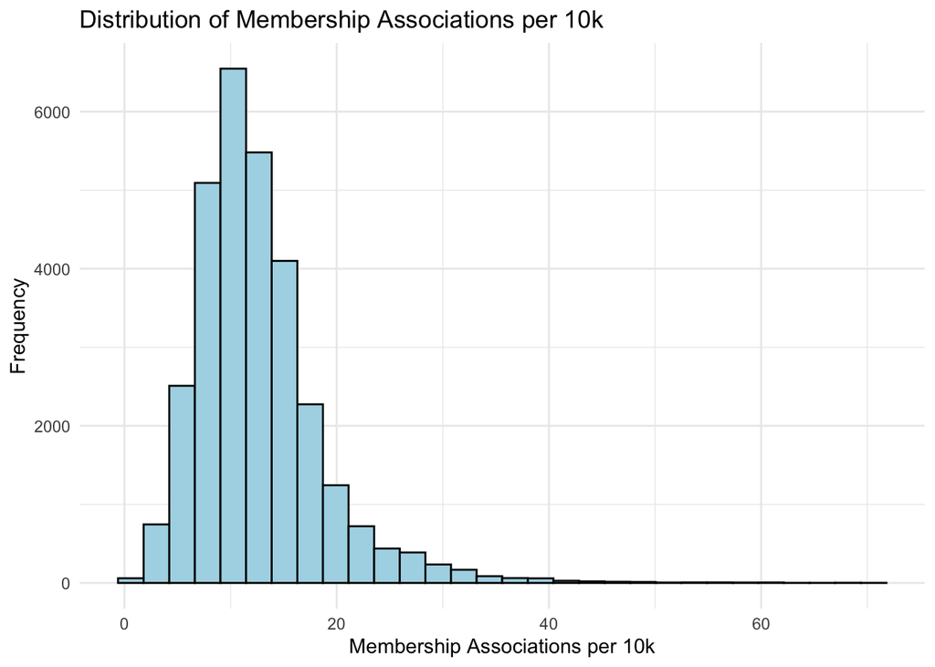

```r
ggplot(merged_associations, aes(x = count_membership_associations_per_10k)) +
  geom_histogram(bins = 30, color = "black", fill = "lightblue") +
  labs(
    title = "Distribution of Membership Associations per 10k",
    x = "Membership Associations per 10k", y = "Frequency"
  ) +
  theme_minimal()
```

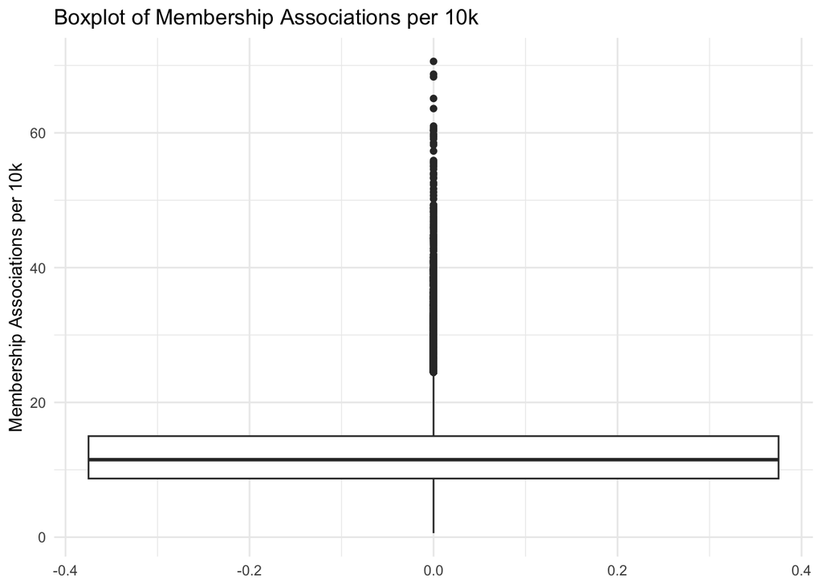

```r
ggplot(merged_associations, aes(y = count_membership_associations_per_10k)) +
  geom_boxplot() +
  labs(
    title = "Boxplot of Membership Associations per 10k",
    y = "Membership Associations per 10k"
  ) +
  theme_minimal()
```

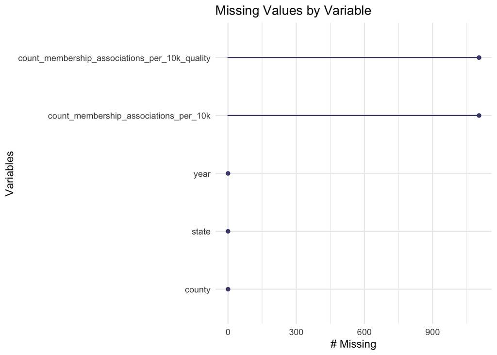

```r
# Visualize missing data
gg_miss_var(merged_associations) +
  labs(title = "Missing Values by Variable")
```

There is a precipitous decline in population-standarized association counts from 2016 to 2017

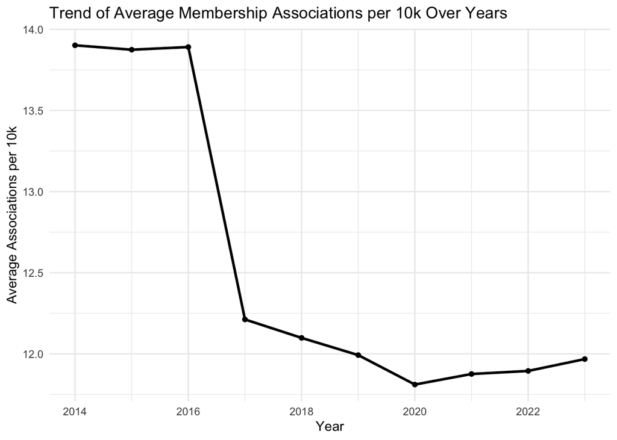

```r
yearly_avg <- merged_associations %>%
  group_by(year) %>%
  summarise(avg_associations = mean(count_membership_associations_per_10k, na.rm = TRUE))

ggplot(yearly_avg, aes(x = year, y = avg_associations)) +
  geom_line(linewidth = 1) +
  geom_point() +
  labs(
    title = "Trend of Average Membership Associations per 10k Over Years",
    x = "Year", y = "Average Associations per 10k"
  ) +
  theme_minimal()
```

## Run Final Tests

```r
source(here("functions/testing/evaluate_final_data.R"))

evaluate_final_data(here("10a_final-evaluation", "evaluation_form_social_cap1_overall_county.csv"), merged_associations, "county", subgroups = FALSE, confidence_intervals = FALSE)
```

```
[1] "This data passes all tests!"
```

## Save the final file

```r
merged_associations %>%
  arrange(year, state, county) %>%
  write_csv(here("06_neighborhoods/social-capital/final/social_associations_all_county.csv"))
```